# Tinker RL Experiments — Overview & Comparison

**PES University MTech Capstone — Group 6** **8th Guidance Call Results**

## Project Summary

This project explores **reinforcement learning for language models** using:

- **GRPO** (Group Relative Policy Optimization) — RL without a value/critic model
- **Tinker API** (Thinking Machines) — cloud-based LoRA training on GPUs
- **Atropos** (NousResearch) — environment framework for generating rollouts

We ran experiments across **2 model families** (Qwen, Llama), **4 model sizes** (3B to 30B), and **2 benchmarks** (GSM8K grade school math, MATH competition math).

## Results Summary

| Experiment | Parameters | Benchmark | Initial Reward | Final Reward | Peak Reward | Steps | Status |
| --- | --- | --- | --- | --- | --- | --- | --- |
| GSM8K - Qwen3-8B | 8.2B | GSM8K | 7.0% | 100.0% | 100.0% | 50 | Complete |
| GSM8K - Qwen3-30B-A3B (MoE) | 30B total / 3B active (MoE) | GSM8K | 17.2% | 99.2% | 100.0% | 50 | Complete |
| GSM8K - Llama 3.1-8B-Instruct | 8B | GSM8K | 78.9% | 100.0% | 100.0% | 50 | Complete |
| GSM8K - Llama 3.2-3B (Base) | 3B | GSM8K | 0.8% | 2.3% | 3.1% | 50 | Complete (Negative Result) |
| MATH Competition - Qwen3-8B | 8.2B | MATH | 3.1% | 12.5% | 18.8% | 29 | In Progress |
| MATH Competition - Llama 3.1-8B-Instruct | 8B | MATH | 66.4% | 86.7% | 96.9% | 50 | In Progress |

## GSM8K Comparison — All Models

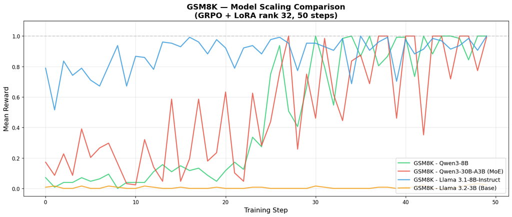

```python
import matplotlib.pyplot as plt
import matplotlib
matplotlib.rcParams['figure.dpi'] = 120

gsm8k_experiments = []

data_gsm8k_qwen_8b = {
    'steps': [0, 1, 2, 3, 4, 5, 6, 7, 8, 9, 10, 11, 12, 13, 14, 15, 16, 17, 18, 19, 20, 21, 22, 23, 24, 25, 26, 27, 28, 29, 30, 31, 32, 33, 34, 35, 36, 37, 38, 39, 40, 41, 42, 43, 44, 45, 46, 47, 48, 49],
    'rewards': [0.0703, 0.0078, 0.0391, 0.0391, 0.0703, 0.0469, 0.0625, 0.0938, 0.0, 0.0391, 0.0391, 0.0391, 0.1094, 0.1562, 0.1094, 0.1484, 0.1172, 0.1328, 0.0859, 0.0469, 0.1172, 0.1719, 0.125, 0.3359, 0.2734, 0.75, 0.9375, 0.5078, 0.4062, 0.6641, 1.0, 0.7969, 0.5469, 0.9844, 1.0, 0.8672, 1.0, 0.8047, 0.8672, 0.9922, 0.9922, 0.7344, 1.0, 0.8828, 1.0, 1.0, 0.9844, 0.8438, 1.0, 1.0],
    'label': 'GSM8K - Qwen3-8B',
}
gsm8k_experiments.append(data_gsm8k_qwen_8b)

data_gsm8k_qwen_30b_moe = {
    'steps': [0, 1, 2, 3, 4, 5, 6, 7, 8, 9, 10, 11, 12, 13, 14, 15, 16, 17, 18, 19, 20, 21, 22, 23, 24, 25, 26, 27, 28, 29, 30, 31, 32, 33, 34, 35, 36, 37, 38, 39, 40, 41, 42, 43, 44, 45, 46, 47, 48, 49],
    'rewards': [0.1719, 0.0859, 0.2266, 0.0859, 0.3906, 0.2031, 0.2656, 0.2969, 0.1641, 0.0312, 0.0234, 0.3203, 0.1406, 0.0469, 0.5859, 0.0469, 0.1953, 0.5859, 0.1797, 0.2344, 0.6328, 0.1016, 0.0469, 0.625, 0.2812, 0.4375, 0.7578, 1.0, 0.2578, 0.75, 0.4609, 0.9844, 0.6172, 0.4453, 0.8359, 0.875, 0.6875, 1.0, 1.0, 0.4609, 1.0, 1.0, 0.3516, 1.0, 1.0, 0.7188, 1.0, 1.0, 0.7734, 0.9922],
    'label': 'GSM8K - Qwen3-30B-A3B (MoE)',
}
gsm8k_experiments.append(data_gsm8k_qwen_30b_moe)

data_gsm8k_llama_8b = {
    'steps': [0, 1, 2, 3, 4, 5, 6, 7, 8, 9, 10, 11, 12, 13, 14, 15, 16, 17, 18, 19, 20, 21, 22, 23, 24, 25, 26, 27, 28, 29, 30, 31, 32, 33, 34, 35, 36, 37, 38, 39, 40, 41, 42, 43, 44, 45, 46, 47, 48, 49],
    'rewards': [0.7891, 0.5156, 0.8359, 0.7422, 0.7891, 0.7109, 0.6719, 0.8047, 0.9375, 0.6719, 0.8672, 0.8594, 0.7812, 0.9609, 0.9531, 0.9297, 0.9922, 0.9609, 0.8828, 0.9766, 0.9219, 0.7891, 0.9219, 0.9375, 0.8828, 0.9766, 0.9922, 0.9531, 0.7734, 0.9531, 0.9531, 0.9297, 0.9062, 0.9844, 0.6875, 1.0, 0.9062, 0.9609, 0.9922, 0.7031, 0.9766, 0.8828, 0.9141, 0.9844, 0.9688, 0.9141, 0.9375, 0.9844, 0.9062, 1.0],
    'label': 'GSM8K - Llama 3.1-8B-Instruct',
}
gsm8k_experiments.append(data_gsm8k_llama_8b)

data_gsm8k_llama_3b = {
    'steps': [0, 1, 2, 3, 4, 5, 6, 7, 8, 9, 10, 11, 12, 13, 14, 15, 16, 17, 18, 19, 20, 21, 22, 23, 24, 25, 26, 27, 28, 29, 30, 31, 32, 33, 34, 35, 36, 37, 38, 39, 40, 41, 42, 43, 44, 45, 46, 47, 48, 49],
    'rewards': [0.0078, 0.0156, 0.0, 0.0, 0.0156, 0.0, 0.0, 0.0156, 0.0078, 0.0, 0.0, 0.0156, 0.0078, 0.0, 0.0, 0.0078, 0.0, 0.0, 0.0, 0.0078, 0.0, 0.0, 0.0, 0.0078, 0.0078, 0.0, 0.0, 0.0, 0.0, 0.0, 0.0156, 0.0078, 0.0, 0.0, 0.0, 0.0, 0.0, 0.0078, 0.0078, 0.0, 0.0078, 0.0078, 0.0234, 0.0, 0.0, 0.0, 0.0078, 0.0234, 0.0312, 0.0234],
    'label': 'GSM8K - Llama 3.2-3B (Base)',
}
gsm8k_experiments.append(data_gsm8k_llama_3b)


colors = ['#2ecc71', '#e74c3c', '#3498db', '#f39c12']
fig, ax = plt.subplots(figsize=(14, 6))

for i, exp in enumerate(gsm8k_experiments):
    ax.plot(exp['steps'], exp['rewards'], color=colors[i % len(colors)],
            linewidth=2, alpha=0.8, label=exp['label'])

ax.set_xlabel('Training Step', fontsize=13)
ax.set_ylabel('Mean Reward', fontsize=13)
ax.set_title('GSM8K — Model Scaling Comparison\n(GRPO + LoRA rank 32, 50 steps)', fontsize=15, fontweight='bold')
ax.set_ylim(-0.05, 1.1)
ax.axhline(y=1.0, color='gray', linestyle='--', alpha=0.3)
ax.grid(True, alpha=0.3)
ax.legend(fontsize=11, loc='lower right')
plt.tight_layout()
plt.show()
```

## MATH Competition Comparison

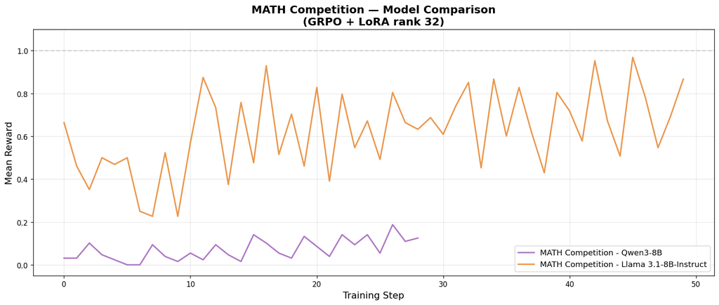

```python
math_experiments = []

data_math_qwen_8b = {
    'steps': [0, 1, 2, 3, 4, 5, 6, 7, 8, 9, 10, 11, 12, 13, 14, 15, 16, 17, 18, 19, 20, 21, 22, 23, 24, 25, 26, 27, 28],
    'rewards': [0.0312, 0.0312, 0.1016, 0.0469, 0.0234, 0.0, 0.0, 0.0938, 0.0391, 0.0156, 0.0547, 0.0234, 0.0938, 0.0469, 0.0156, 0.1406, 0.1016, 0.0547, 0.0312, 0.1328, 0.0859, 0.0391, 0.1406, 0.0938, 0.1406, 0.0547, 0.1875, 0.1094, 0.125],
    'label': 'MATH Competition - Qwen3-8B',
}
math_experiments.append(data_math_qwen_8b)

data_math_llama_8b = {
    'steps': [0, 1, 2, 3, 4, 5, 6, 7, 8, 9, 10, 11, 12, 13, 14, 15, 16, 17, 18, 19, 20, 21, 22, 23, 24, 25, 26, 27, 28, 29, 30, 31, 32, 33, 34, 35, 36, 37, 38, 39, 40, 41, 42, 43, 44, 45, 46, 47, 48, 49],
    'rewards': [0.6641, 0.4609, 0.3516, 0.5, 0.4688, 0.5, 0.25, 0.2266, 0.5234, 0.2266, 0.5703, 0.875, 0.7344, 0.375, 0.7578, 0.4766, 0.9297, 0.5156, 0.7031, 0.4609, 0.8281, 0.3906, 0.7969, 0.5469, 0.6719, 0.4922, 0.8047, 0.6641, 0.6328, 0.6875, 0.6094, 0.7422, 0.8516, 0.4531, 0.8672, 0.6016, 0.8281, 0.6172, 0.4297, 0.8047, 0.7188, 0.5781, 0.9531, 0.6719, 0.5078, 0.9688, 0.7812, 0.5469, 0.6953, 0.8672],
    'label': 'MATH Competition - Llama 3.1-8B-Instruct',
}
math_experiments.append(data_math_llama_8b)


colors = ['#9b59b6', '#e67e22']
fig, ax = plt.subplots(figsize=(14, 6))

for i, exp in enumerate(math_experiments):
    ax.plot(exp['steps'], exp['rewards'], color=colors[i % len(colors)],
            linewidth=2, alpha=0.8, label=exp['label'])

ax.set_xlabel('Training Step', fontsize=13)
ax.set_ylabel('Mean Reward', fontsize=13)
ax.set_title('MATH Competition — Model Comparison\n(GRPO + LoRA rank 32)', fontsize=15, fontweight='bold')
ax.set_ylim(-0.05, 1.1)
ax.axhline(y=1.0, color='gray', linestyle='--', alpha=0.3)
ax.grid(True, alpha=0.3)
ax.legend(fontsize=11)
plt.tight_layout()
plt.show()
```

## Key Insights

### 2. Base vs Instruct Models

- **Qwen3-8B (base)**: 7% → 100% over 50 steps (slow initial ramp)
- **Llama-3.1-8B (instruct)**: 79% → 100% in 35 steps (massive head start)
- Instruct fine-tuning provides strong prior knowledge for structured tasks

### 3. MoE Efficiency

- **Qwen3-30B-A3B (MoE)**: Only 3B active parameters, yet reaches 99.2%
- More cost-effective than a dense 30B model at inference time
- Slightly more volatile training than dense models

### 4. GSM8K vs MATH Difficulty

- GSM8K (grade school): Most models reach 90-100% quickly
- MATH (competition): Much harder — Qwen-8B only reaches ~14% after 25 steps
- Llama-8B-Instruct does better on MATH (~55-87%) due to instruct pretraining

## Method: GRPO (Group Relative Policy Optimization)

GRPO trains language models through reinforcement learning **without a value/critic model**:

1. **Group Sampling**: For each question, generate N completions (group_size=16)
2. **Binary Reward**: Each completion is scored 0 (wrong) or 1 (correct) via symbolic math verification
3. **Relative Advantage**: Within each group, compute advantages relative to the group mean
4. **Policy Update**: Update model using importance-sampled policy gradient with LoRA adapters

```
Advantage_i = Reward_i - mean(Rewards_group)

Loss = -sum(IS_ratio * Advantage * log_prob)
     where IS_ratio = P_new(token) / P_old(token)
```

This eliminates the need for a separate value network, reducing memory and compute costs.